# ANOVA and Post-Hoc Analysis Tutorial

Your Name

2024-11-25

## Introduction

In this tutorial, we will analyze simulated data to determine if there are significant differences between group means using **ANOVA**. We will follow this with pairwise t-tests using the **Bonferroni correction** to identify specific group differences.

## Visualizing the Data

Let’s visualize the distributions of the groups using a boxplot.

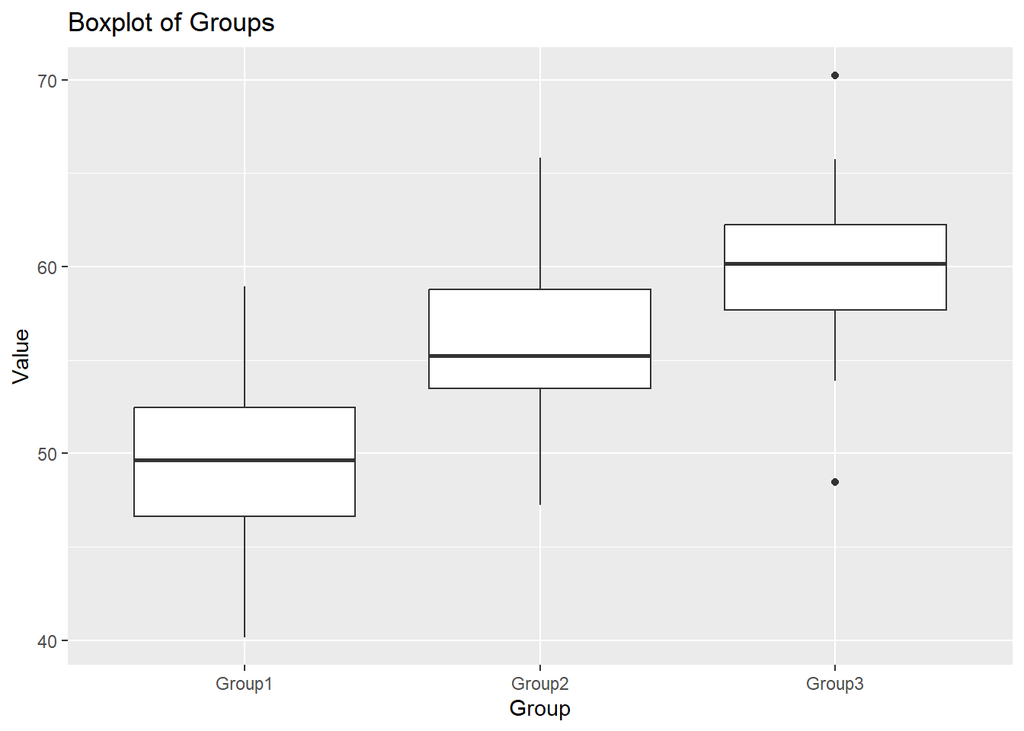

```r
ggplot(data, aes(x = Group, y = Value)) +
  geom_boxplot() +
  labs(title = "Boxplot of Groups", x = "Group", y = "Value")
```

## Conducting ANOVA

We will perform an **ANOVA** to test the null hypothesis that all groups have the same mean. The alternative hypothesis is that at least one group differs.

```r
# Run ANOVA
anova_result <- aov(Value ~ Group, data = data)

# Print ANOVA summary
summary(anova_result)
```

```
##             Df Sum Sq Mean Sq F value   Pr(>F)
## Group        2   1627   813.6    40.4 3.89e-13 ***
## Residuals   87   1752    20.1
## ---
## Signif. codes:  0 '***' 0.001 '**' 0.01 '*' 0.05 '.' 0.1 ' ' 1
```

### Interpretation

If the p-value from the ANOVA summary is less than 0.05, we reject the null hypothesis and conclude that there are differences among the group means.

## Simulating a Second Dataset: Lecture Scores Example

For further analysis, let’s simulate another dataset representing midterm scores from three lecture groups.

- **Scenario**: The data represents midterm scores for students in three lecture groups (A, B, and C) of the same statistics course.
- **Purpose**: To determine if there are significant differences in the mean midterm scores among the three lectures.
- **Group Details**:
  - **Lecture A**: 58 students, mean = 69.1, standard deviation = 13.2.
  - **Lecture B**: 55 students, mean = 71.0, standard deviation = 13.4.
  - **Lecture C**: 51 students, mean = 78.9, standard deviation = 13.11.
- **Analysis Approach**:
  1. Perform an **ANOVA** to test if the mean scores differ across lectures.
  2. If the null hypothesis is rejected, use pairwise t-tests with **Bonferroni correction** to identify specific differences between groups.

```r
# Set seed for reproducibility
set.seed(123)

# Simulate dataset
data_lecture <- data.frame(
  Score = c(
    rnorm(58, mean = 69.1, sd = 13.2),  # Lecture A
    rnorm(55, mean = 71.0, sd = 13.4),  # Lecture B
    rnorm(51, mean = 78.9, sd = 13.11)   # Lecture C
  ),
  Lecture = factor(rep(c("A", "B", "C"), times = c(58, 55, 51)))
)

# Conduct ANOVA
anova_result_lecture <- aov(Score ~ Lecture, data = data_lecture)

# Print ANOVA summary
summary(anova_result_lecture)
```

```
##              Df Sum Sq Mean Sq F value  Pr(>F)
## Lecture       2   1990   995.2   6.019 0.00301 **
## Residuals   161  26619   165.3
## ---
## Signif. codes:  0 '***' 0.001 '**' 0.01 '*' 0.05 '.' 0.1 ' ' 1
```

## Pairwise Comparisons with Bonferroni Correction

After rejecting the null hypothesis in ANOVA, we perform pairwise comparisons using **Bonferroni correction** to control the Type I error rate.

```r
# Pairwise t-tests with Bonferroni correction
pairwise_result <- pairwise.t.test(
  data_lecture$Score,  # Numeric data
  data_lecture$Lecture,  # Grouping factor
  p.adjust.method = "bonferroni"  # Bonferroni correction
)

# Print pairwise test results
pairwise_result
```

```
##
##  Pairwise comparisons using t tests with pooled SD
##
## data:  data_lecture$Score and data_lecture$Lecture
##
##   A      B
## B 1.0000 -
## C 0.0045 0.0188
##
## P value adjustment method: bonferroni
```

### Interpretation

The Bonferroni correction adjusts the significance level for each test. This ensures that the overall Type I error rate remains controlled.

## Visualizing the Lecture Data

Let’s visualize the scores by lecture group using a boxplot.

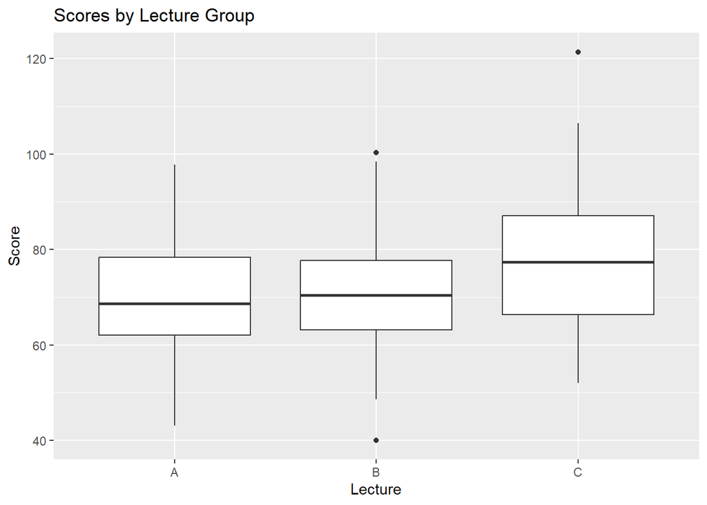

```r
ggplot(data_lecture, aes(x = Lecture, y = Score)) +
  geom_boxplot() +
  labs(title = "Scores by Lecture Group", x = "Lecture", y = "Score")
```

## Summary of Results

This demonstrates the importance of post-hoc analysis in identifying specific group differences after rejecting the null hypothesis in ANOVA.

### Adding an Example for Testing Proportions with ANOVA and Pairwise T-Tests

ANOVA and post-hoc analyses can also be applied to datasets involving proportions (binary data), where the goal is to test differences in success probabilities between groups. Here, we simulate binary (Bernoulli-distributed) data to analyze group differences.

## Case Study: Proportion of Successes in Experimental Groups

### Scenario

We want to test if there is a significant difference in the proportion of successes between three groups in an experiment.

- **Group Details**:
  - **Group A**: 100 observations, success rate = 0.3.
  - **Group B**: 100 observations, success rate = 0.5.
  - **Group C**: 100 observations, success rate = 0.7.
- **Analysis Approach**:
  1. Perform an ANOVA test on the proportions to determine if at least one group differs in success rate.
  2. Conduct pairwise comparisons with **Bonferroni correction** if the null hypothesis is rejected.

### Simulating the Dataset

```r
# Set seed for reproducibility
set.seed(123)

# Generate binary data for three groups
data_bernoulli <- data.frame(
  Success = c(
    rbinom(100, 1, 0.3),  # Group A
    rbinom(100, 1, 0.5),  # Group B
    rbinom(100, 1, 0.7)   # Group C
  ),
  Group = factor(rep(c("A", "B", "C"), each = 100))
)

# Preview the first few rows of the dataset
head(data_bernoulli)
```

```
##   Success Group
## 1       0     A
## 2       1     A
## 3       0     A
## 4       1     A
## 5       1     A
## 6       0     A
```

### Visualizing Proportions by Group

A bar plot is a useful way to visualize proportions.

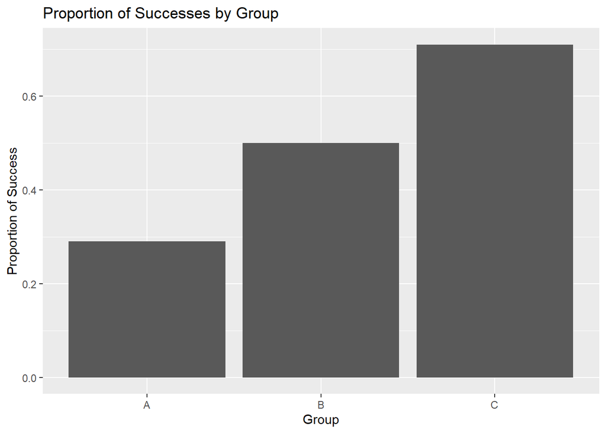

```r
data_bernoulli_summary <- data_bernoulli %>%
  group_by(Group) %>%
  summarize(Proportion = mean(Success))

ggplot(data_bernoulli_summary, aes(x = Group, y = Proportion)) +
  geom_bar(stat = "identity") +
  labs(title = "Proportion of Successes by Group", x = "Group", y = "Proportion of Success")
```

### Conducting ANOVA for Proportions

We use an ANOVA model to compare group means (proportions of successes).

```r
# Conduct ANOVA
anova_result_bernoulli <- aov(Success ~ Group, data = data_bernoulli)

# Print ANOVA summary
summary(anova_result_bernoulli)
```

```
##              Df Sum Sq Mean Sq F value   Pr(>F)
## Group         2   8.82   4.410   19.79 8.54e-09 ***
## Residuals   297  66.18   0.223
## ---
## Signif. codes:  0 '***' 0.001 '**' 0.01 '*' 0.05 '.' 0.1 ' ' 1
```

### Interpretation

If the p-value from the ANOVA summary is less than 0.05, we reject the null hypothesis and conclude that there are differences in success proportions among the groups.

### Pairwise Comparisons with Bonferroni Correction

If the ANOVA test is significant, pairwise t-tests can be used to identify specific group differences.

```r
# Perform pairwise comparisons with Bonferroni correction
pairwise_result_bernoulli <- pairwise.t.test(
  data_bernoulli$Success,  # Binary response variable
  data_bernoulli$Group,    # Grouping factor
  p.adjust.method = "bonferroni"  # Bonferroni correction
)

# Print pairwise test results
pairwise_result_bernoulli
```

```
##
##  Pairwise comparisons using t tests with pooled SD
##
## data:  data_bernoulli$Success and data_bernoulli$Group
##
##   A       B
## B 0.0055  -
## C 3.4e-09 0.0055
##
## P value adjustment method: bonferroni
```

### Interpretation of Results

- **ANOVA**: A significant p-value indicates that at least one group’s success proportion differs from the others.
- **Pairwise Comparisons**:
  - Adjusted p-values reveal which group pairs differ significantly in their success proportions.

### Summary of Bernoulli Case Study

1. **ANOVA Results**:
   - The ANOVA test determines if there are overall differences in success proportions between groups.
2. **Pairwise Comparisons**:
   - Post-hoc pairwise tests with Bonferroni correction pinpoint specific group differences.

### Visualizing Proportions with Error Bars

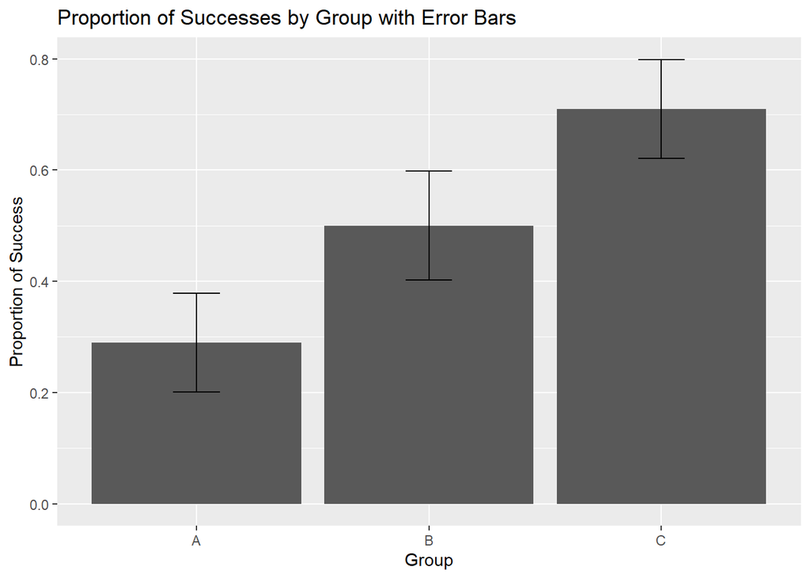

```r
ggplot(data_bernoulli_summary, aes(x = Group, y = Proportion)) +
  geom_bar(stat = "identity") +
  geom_errorbar(aes(ymin = Proportion - 1.96 * sqrt((Proportion * (1 - Proportion)) / 100),
                    ymax = Proportion + 1.96 * sqrt((Proportion * (1 - Proportion)) / 100)), width = 0.2) +
  labs(title = "Proportion of Successes by Group with Error Bars", x = "Group", y = "Proportion of Success")
```

This case demonstrates how ANOVA and post-hoc analysis can be applied to binary data, providing insight into differences in proportions among groups.